# Telco Churn

```r
knitr::opts_chunk$set(echo = T, warning = FALSE)
```

## Descrição do Problema e da Base de Dados

Contexto:

Preveja o comportamento para reter clientes. Você pode analisar todos os dados relevantes do cliente e desenvolver programas focados na retenção de clientes.

Conteúdo:

Cada linha representa um cliente, cada coluna contém os atributos do cliente descritos na coluna Metadados.

O conjunto de dados inclui informações sobre:

Clientes que saíram no último mês - a coluna é chamada de rotatividade (Churn)

Serviços que cada cliente assinou - telefone, várias linhas, internet, segurança online, backup online, proteção de dispositivo, suporte técnico e streaming de TV e filmes

Informações da conta do cliente - há quanto tempo ele é cliente, contrato, forma de pagamento, faturamento sem papel, cobranças mensais e cobranças totais

Informações demográficas sobre clientes - sexo, faixa etária e se eles têm parceiros e dependentes

### Importando as bibliotecas

```r
library(tidyverse)
library(MASS)
library(car)
library(e1071)
library(caret)
library(cowplot)
library(caTools)
library(pROC)
library(ggcorrplot)
library(naniar)
library(gridExtra)
library(corrplot)
```

### Importando a base de dados

```r
telco <- read_csv("C:/Users/Pichau/Documents/Kaggle/Telco Churn/telco_data.csv")
glimpse(telco)
```

```
## Rows: 7,043
## Columns: 21
## $ customerID       <chr> "7590-VHVEG", "5575-GNVDE", "3668-QPYBK", "7795-CF...
## $ gender           <chr> "Female", "Male", "Male", "Male", "Female", "Femal...
## $ SeniorCitizen    <dbl> 0, 0, 0, 0, 0, 0, 0, 0, 0, 0, 0, 0, 0, 0, 0, 0, 0,...
## $ Partner          <chr> "Yes", "No", "No", "No", "No", "No", "No", "No", "...
## $ Dependents       <chr> "No", "No", "No", "No", "No", "No", "Yes", "No", "...
## $ tenure           <dbl> 1, 34, 2, 45, 2, 8, 22, 10, 28, 62, 13, 16, 58, 49...
## $ PhoneService     <chr> "No", "Yes", "Yes", "No", "Yes", "Yes", "Yes", "No...
## $ MultipleLines    <chr> "No phone service", "No", "No", "No phone service"...
## $ InternetService  <chr> "DSL", "DSL", "DSL", "DSL", "Fiber optic", "Fiber ...
## $ OnlineSecurity   <chr> "No", "Yes", "Yes", "Yes", "No", "No", "No", "Yes"...
## $ OnlineBackup     <chr> "Yes", "No", "Yes", "No", "No", "No", "Yes", "No",...
## $ DeviceProtection <chr> "No", "Yes", "No", "Yes", "No", "Yes", "No", "No",...
## $ TechSupport      <chr> "No", "No", "No", "Yes", "No", "No", "No", "No", "...
## $ StreamingTV      <chr> "No", "No", "No", "No", "No", "Yes", "Yes", "No", ...
## $ StreamingMovies  <chr> "No", "No", "No", "No", "No", "Yes", "No", "No", "...
## $ Contract         <chr> "Month-to-month", "One year", "Month-to-month", "O...
## $ PaperlessBilling <chr> "Yes", "No", "Yes", "No", "Yes", "Yes", "Yes", "No...
## $ PaymentMethod    <chr> "Electronic check", "Mailed check", "Mailed check"...
## $ MonthlyCharges   <dbl> 29.85, 56.95, 53.85, 42.30, 70.70, 99.65, 89.10, 2...
## $ TotalCharges     <dbl> 29.85, 1889.50, 108.15, 1840.75, 151.65, 820.50, 1...
## $ Churn            <chr> "No", "No", "Yes", "No", "Yes", "Yes", "No", "No",...
```

### Checando variáveis com valores faltantes

```r
miss_var_which(telco)
```

```
## [1] "TotalCharges"
```

Apenas a variável TotalCharges possui valores faltantes. Foram contabilizados 11 valores faltantes que representam 0.15% do total

```r
miss_var_summary(telco)
```

| variable | n_miss | pct_miss |
| --- | --- | --- |
| TotalCharges | 11 | 0.1561834 |
| customerID | 0 | 0.0000000 |
| gender | 0 | 0.0000000 |
| SeniorCitizen | 0 | 0.0000000 |
| Partner | 0 | 0.0000000 |
| Dependents | 0 | 0.0000000 |
| tenure | 0 | 0.0000000 |
| PhoneService | 0 | 0.0000000 |
| MultipleLines | 0 | 0.0000000 |
| InternetService | 0 | 0.0000000 |

[output cut: 11 more lines]

Como são poucas variaveis faltantes, irei excluí-las

```r
telco <- telco %>% filter(!is.na(TotalCharges))
```

Em seguida irei transformar para categórico a variáveil SeniorCitizen

```r
telco$SeniorCitizen <- ifelse(telco$SeniorCitizen == 1, "Yes", "No")
```

Transformando para “factor” as variaveis categoricas que estavam como “chr”

```r
cols <- c(2:5,7:18,21)
telco[,cols] <- lapply(telco[,cols], as.factor)
```

```r
glimpse(telco)
```

```
## Rows: 7,032
## Columns: 21
## $ customerID       <chr> "7590-VHVEG", "5575-GNVDE", "3668-QPYBK", "7795-CF...
## $ gender           <fct> Female, Male, Male, Male, Female, Female, Male, Fe...
## $ SeniorCitizen    <fct> No, No, No, No, No, No, No, No, No, No, No, No, No...
## $ Partner          <fct> Yes, No, No, No, No, No, No, No, Yes, No, Yes, No,...
## $ Dependents       <fct> No, No, No, No, No, No, Yes, No, No, Yes, Yes, No,...
## $ tenure           <dbl> 1, 34, 2, 45, 2, 8, 22, 10, 28, 62, 13, 16, 58, 49...
## $ PhoneService     <fct> No, Yes, Yes, No, Yes, Yes, Yes, No, Yes, Yes, Yes...
## $ MultipleLines    <fct> No phone service, No, No, No phone service, No, Ye...
## $ InternetService  <fct> DSL, DSL, DSL, DSL, Fiber optic, Fiber optic, Fibe...
## $ OnlineSecurity   <fct> No, Yes, Yes, Yes, No, No, No, Yes, No, Yes, Yes, ...
## $ OnlineBackup     <fct> Yes, No, Yes, No, No, No, Yes, No, No, Yes, No, No...
## $ DeviceProtection <fct> No, Yes, No, Yes, No, Yes, No, No, Yes, No, No, No...
## $ TechSupport      <fct> No, No, No, Yes, No, No, No, No, Yes, No, No, No i...
## $ StreamingTV      <fct> No, No, No, No, No, Yes, Yes, No, Yes, No, No, No ...
## $ StreamingMovies  <fct> No, No, No, No, No, Yes, No, No, Yes, No, No, No i...
## $ Contract         <fct> Month-to-month, One year, Month-to-month, One year...
## $ PaperlessBilling <fct> Yes, No, Yes, No, Yes, Yes, Yes, No, Yes, No, Yes,...
## $ PaymentMethod    <fct> Electronic check, Mailed check, Mailed check, Bank...
## $ MonthlyCharges   <dbl> 29.85, 56.95, 53.85, 42.30, 70.70, 99.65, 89.10, 2...
## $ TotalCharges     <dbl> 29.85, 1889.50, 108.15, 1840.75, 151.65, 820.50, 1...
## $ Churn            <fct> No, No, Yes, No, Yes, Yes, No, No, Yes, No, No, No...
```

## Visualização do Dataset

Percentagem de Churn = Yes e Churn = No

```r
churn_pct <- telco %>%
    count(Churn = Churn) %>%
    mutate(pct = prop.table(n))
```

### Visualizando a variável Target Churn

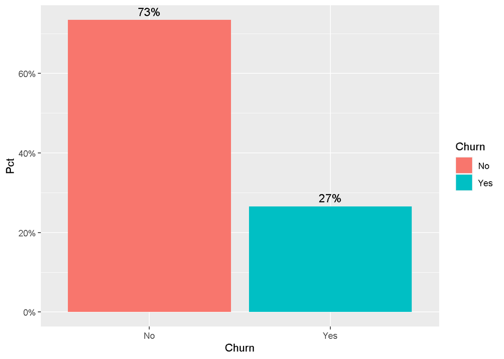

```r
ggplot(churn_pct, aes(x = Churn, y=pct, fill = Churn, label = scales::percent(pct))) +
  geom_col(position="dodge") +
  geom_text(position = position_dodge(width = .9),    # move to center of bars
              vjust = -0.5,    # nudge above top of bar
              size = 4) +
  scale_y_continuous(labels = scales::percent) +
  labs(x = 'Churn', y = 'Pct')
```

### Visualização das variáveis categóricas.

```r
a1 <- ggplot(telco, aes(x = gender, fill = Churn)) +
  geom_bar(position="fill")
```

```r
a2 <- ggplot(telco, aes(x = SeniorCitizen, fill = Churn)) +
  geom_bar(position="fill")
```

```r
a3 <- ggplot(telco, aes(x = Partner, fill = Churn)) +
  geom_bar(position="fill")
```

```r
a4 <- ggplot(telco, aes(x = Dependents, fill = Churn)) +
  geom_bar(position="fill")
```

```r
a5 <- ggplot(telco, aes(x = PhoneService, fill = Churn)) +
  geom_bar(position="fill")
```

```r
a6 <- ggplot(telco, aes(x = MultipleLines, fill = Churn)) +
  geom_bar(position="fill")
```

A taxa de Churn é praticamente igual entre os generos Masculinos e Femininos, e no caso do consumidor ter um serviço de telefone A taxa de Churn é maior no caso de Senior Citizens A taxa de Churn é menor no caso do consumidor ter um parceiro ou ter dependentes A taxa de Churn é maior no caso do consumidor ter um multiplas linhas, porém a diferença é pequena

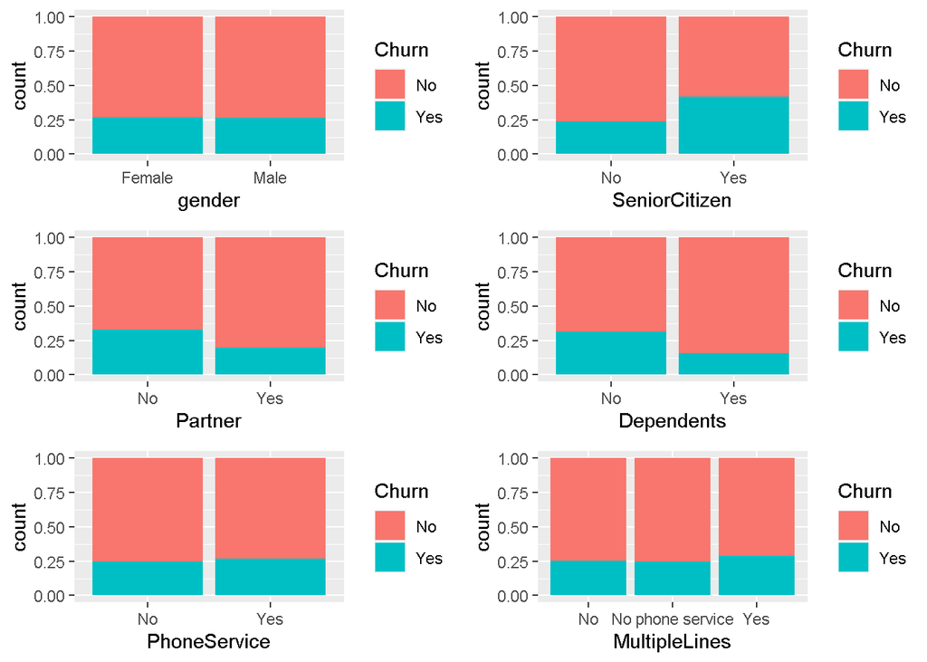

```r
grid.arrange(a1,a2,a3,a4,a5,a6,ncol =2)
```

```r
b1 <- ggplot(telco, aes(x = InternetService, fill = Churn)) +
  geom_bar(position="fill")
```

```r
b2 <- ggplot(telco, aes(x = OnlineSecurity, fill = Churn)) +
  geom_bar(position="fill")
```

```r
b3 <- ggplot(telco, aes(x = OnlineBackup, fill = Churn)) +
  geom_bar(position="fill")
```

```r
b4 <- ggplot(telco, aes(x = DeviceProtection, fill = Churn)) +
  geom_bar(position="fill")
```

```r
b5 <- ggplot(telco, aes(x = TechSupport, fill = Churn)) +
  geom_bar(position="fill")
```

```r
b6 <- ggplot(telco, aes(x = StreamingTV, fill = Churn)) +
  geom_bar(position="fill")
```

A taxa de Churn é bem maior no caso do consumidor ter um serviço de internet com fibra óptica, menor no caso do serviço ser DSL e muito baixa se não tiver serviço de internet. A taxa de Churn é maior no caso do consumidor não ter o serviço OnlineBackup. Menor no caso de ter o serviço OnlineBackup e muito baixa no caso de não ter serviço de internet. No caso do serviço OnlineSecurity, DeviceProtection, TechSupport as ocorrências de Churn são semelhantes. O serviço de StreamingTV apresenta uma taxa de Churn um pouco maior no caso positivo para este serviço em relação aos casos positivos dos ultimos 4 serviços citados acima. O que pode indicar que este serviço possui uma maior relação com a taxa de Churn.

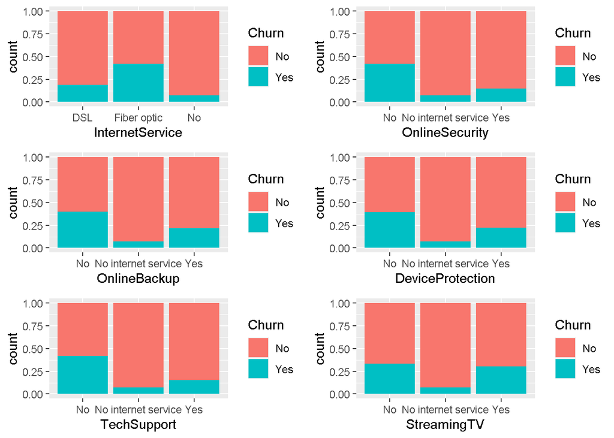

```r
grid.arrange(b1,b2,b3,b4,b5,b6,ncol=2)
```

```r
c1 <- ggplot(telco, aes(x = StreamingMovies, fill = Churn)) +
  geom_bar(position="fill")
```

```r
c2 <- ggplot(telco, aes(x = Contract, fill = Churn)) +
  geom_bar(position="fill")
```

```r
c3 <- ggplot(telco, aes(x = PaperlessBilling, fill = Churn)) +
  geom_bar(position="fill")
```

A taxa de Churn é um pouco superior no caso de não ter StreamingMovies em relação a ter StreamingMovies. No caso do consumidor ter PaperlessBilling a taxa de Churn é superior. Conforme aumenta o tempo do termo do contrato a taxa de Churn diminui. Onde de mês a mês a taxa de Churn é bem elevada.

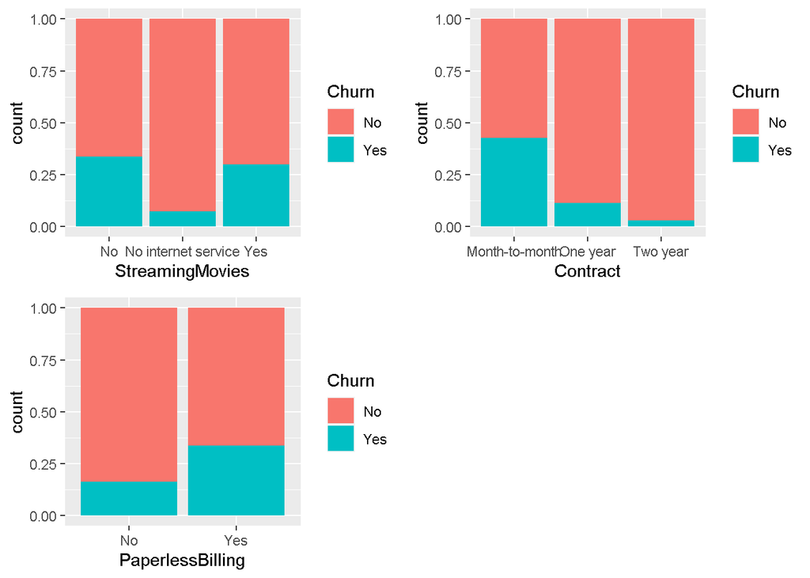

```r
grid.arrange(c1,c2,c3,ncol=2)
```

No caso do pagamento ser Electronic check a taxa de Churn é mais alta, enquanto que para os outros meios a taxa de Churn é semelhante. Em ordem ficou, Electronic check, Mailed check, Bank transfer(automatic) e Credit card (automatic).

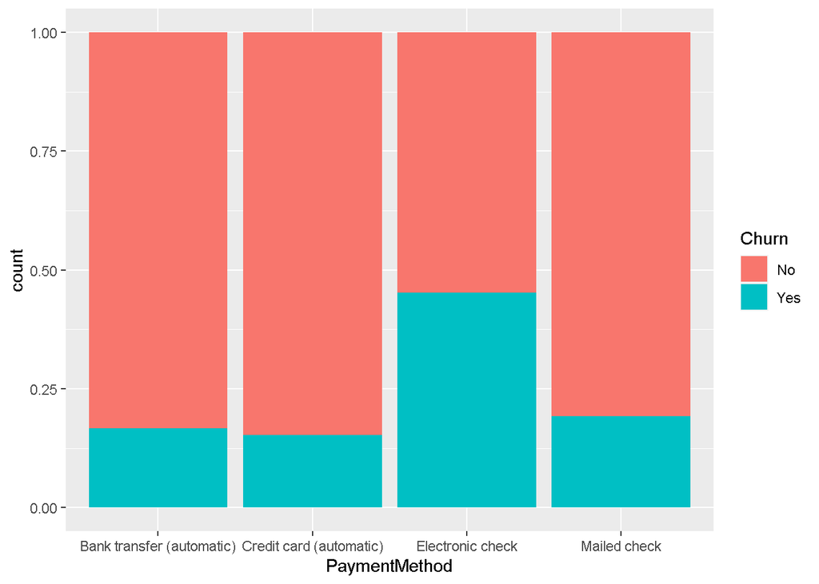

```r
ggplot(telco, aes(x = PaymentMethod, fill = Churn)) +
  geom_bar(position="fill")
```

MonthlyCharges possui distribuição asssimetrica

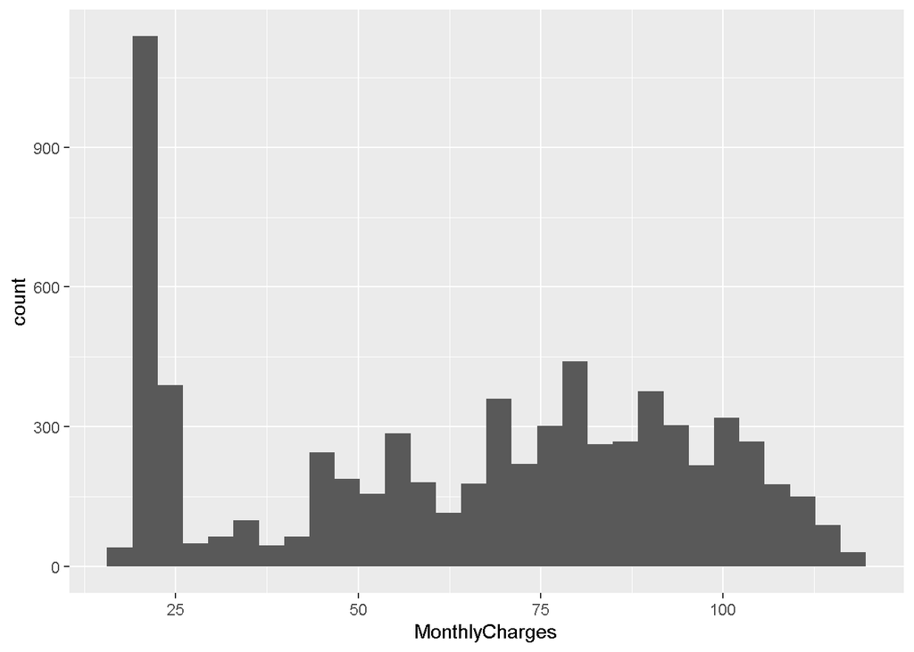

```r
ggplot(telco, aes(x=MonthlyCharges)) + geom_histogram()
```

Tenure possui distribuição assimetrica

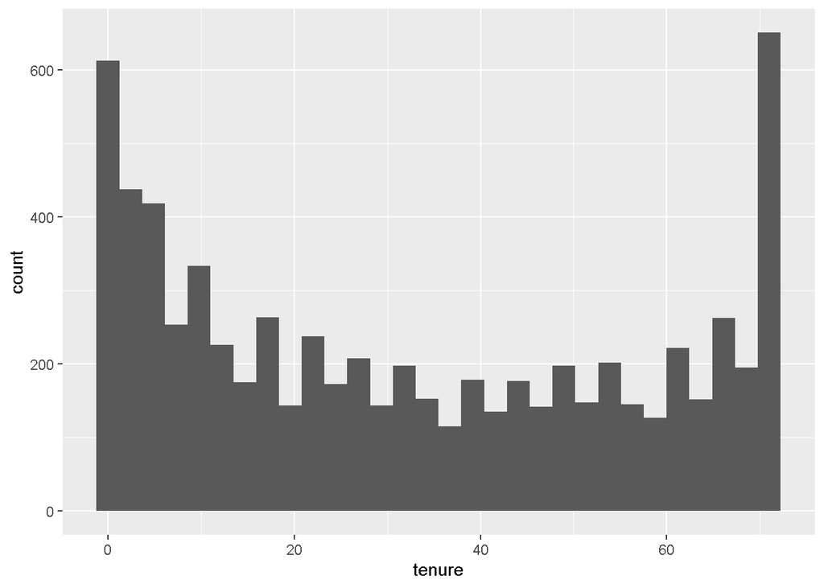

```r
ggplot(telco, aes(x=tenure)) + geom_histogram()
```

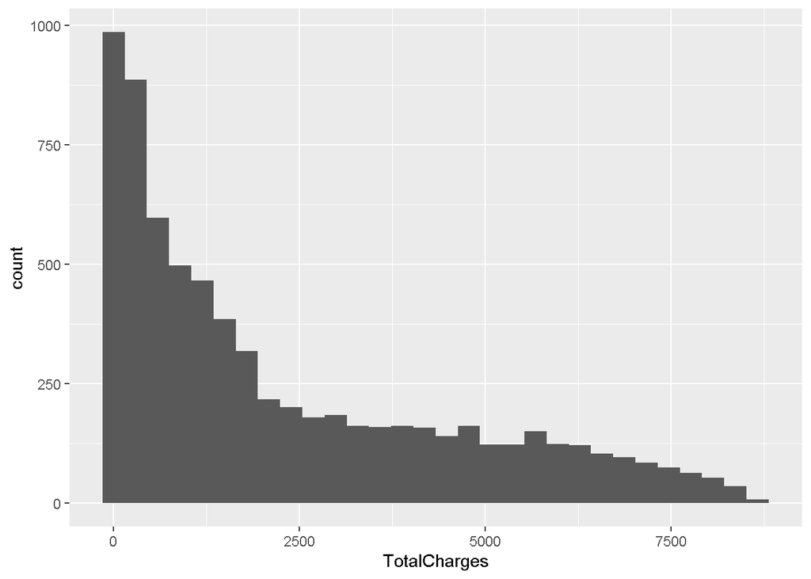

```r
ggplot(telco, aes(x=TotalCharges)) + geom_histogram()
```

### Visualização das variáveis Continuas

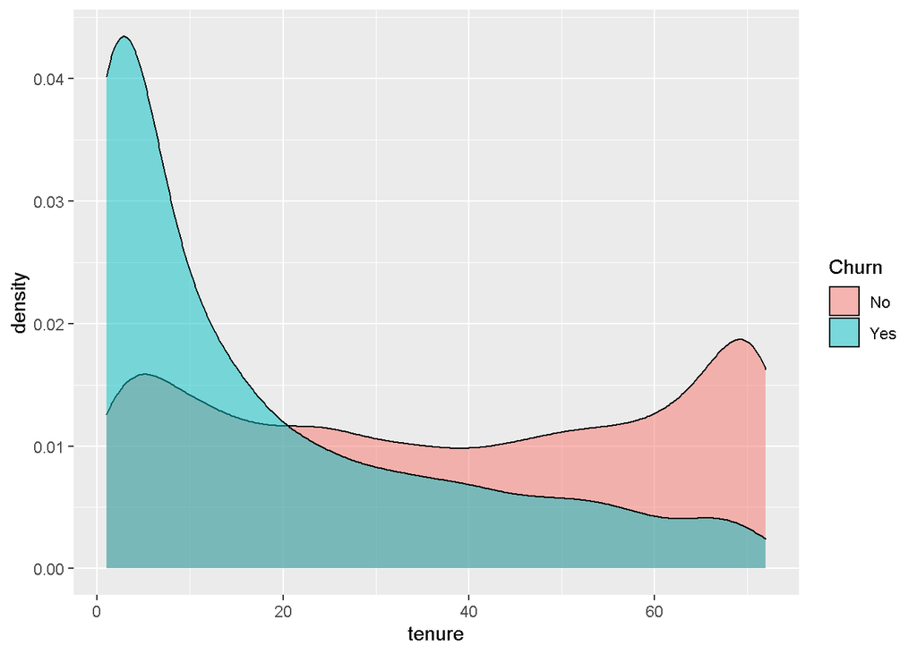

```r
ggplot(telco, aes(x = tenure, fill = Churn)) +
  geom_density(alpha = 0.5)
```

**Tenure:**Pode-se observar que a mediana para clientes que deixaram de ser clientes é de 10 meses e para clientes que continuaram é de 38 meses. Também é possível observar alguns pontos outliers a partir de 70 meses para os clientes que sairam.

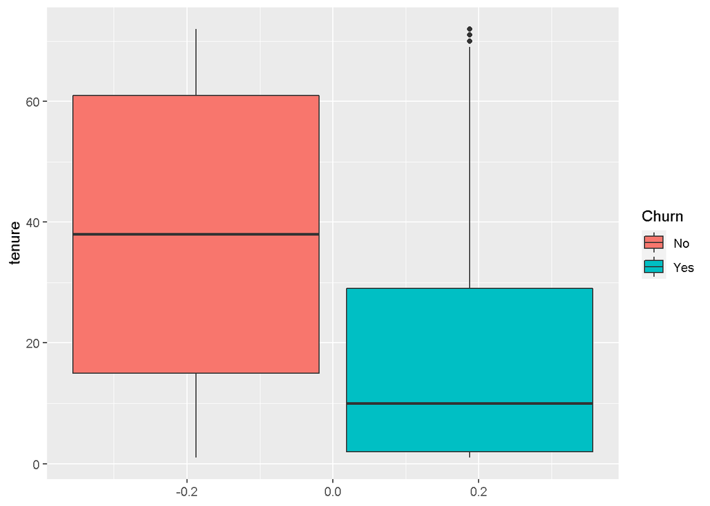

```r
ggplot(telco, aes(y = tenure, fill = Churn)) +
  geom_boxplot()
```

```r
telco %>% filter(Churn == "Yes") %>% summarize(median(tenure))
```

| median(tenure) |
| --- |
| 10 |

```r
telco %>% filter(Churn == "No") %>% summarize(median(tenure))
```

| median(tenure) |
| --- |
| 38 |

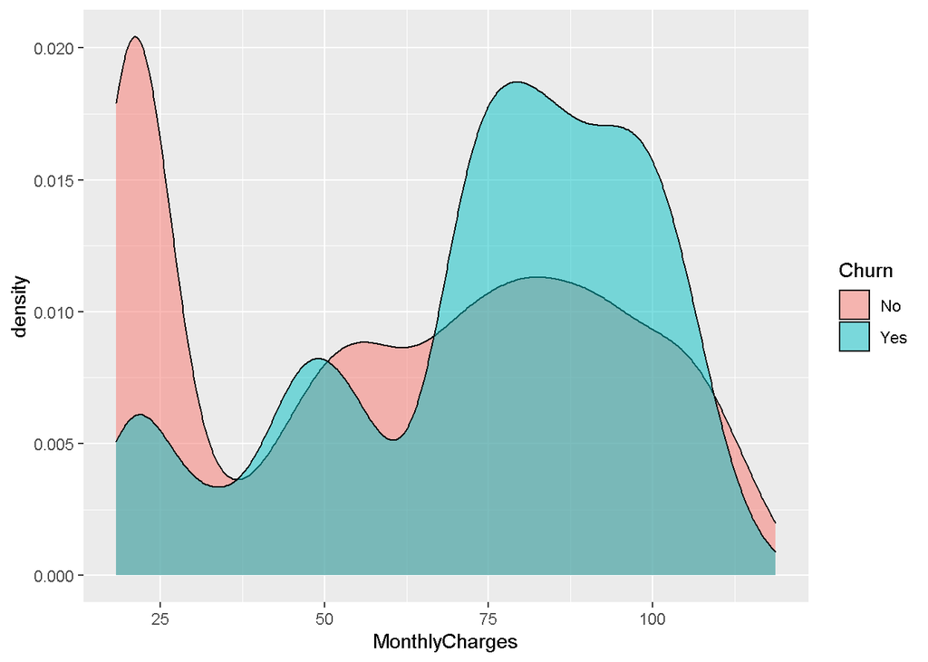

```r
ggplot(telco, aes(x = MonthlyCharges, fill = Churn)) +
  geom_density(alpha = 0.5)
```

**MonthlyCharges:**Pode-se observar que clientes que sairam da base de clientes possuem cobranças mensais maiores, onde a mediana foi de 79.65. E clientes que continuaram possuem mediana um pouco acima de 64.45.

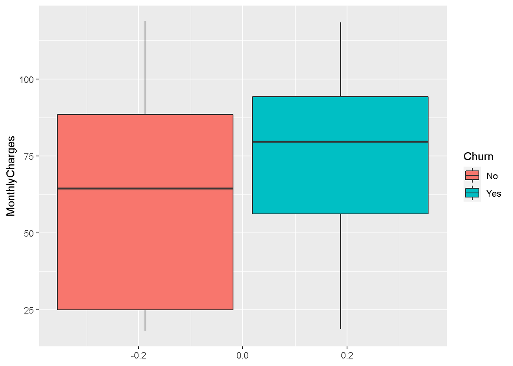

```r
ggplot(telco, aes(y = MonthlyCharges, fill = Churn)) +
  geom_boxplot()
```

```r
telco %>% filter(Churn == "Yes") %>% summarize(median(MonthlyCharges))
```

| median(MonthlyCharges) |
| --- |
| 79.65 |

```r
telco %>% filter(Churn == "No") %>% summarize(median(MonthlyCharges))
```

| median(MonthlyCharges) |
| --- |
| 64.45 |

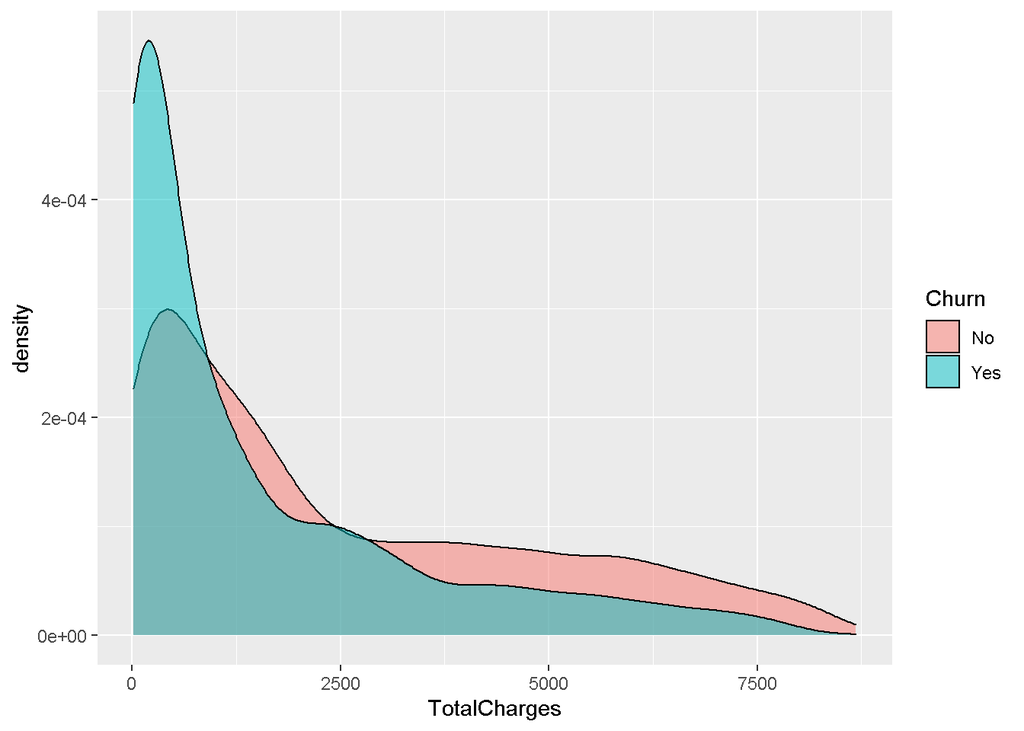

```r
ggplot(telco, aes(x = TotalCharges, fill = Churn)) +
  geom_density(alpha = 0.5)
```

**TotalCharges:**Pode-se observar que clientes deixaram de comprar o serviço da empresa apresentaram cobranças totais (TotalCharges) mais baixas. A mediana para clientes que sairam da base de clientes foi de 703.55, enquanto que para clientes que ficaram a mediana foi de 1683.60. Também é possível observar um numero significativo de outliers no caso de clientes que sairam e que as cobranças totais (TotalCharges) ficaram um pouco acima de 5.625.

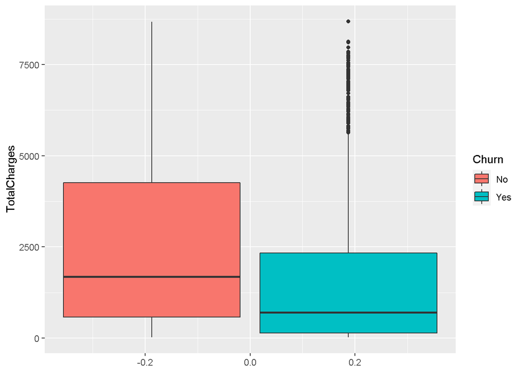

```r
ggplot(telco, aes(y = TotalCharges, fill = Churn)) +
  geom_boxplot()
```

```r
telco %>% filter(Churn == "Yes") %>% summarize(median(TotalCharges))
```

| median(TotalCharges) |
| --- |
| 703.55 |

```r
telco %>% filter(Churn == "No") %>% summarize(median(TotalCharges))
```

| median(TotalCharges) |
| --- |
| 1683.6 |

### Verificando o Balanceamento da variável resposta Churn

```r
table(telco$Churn)[1]
```

```
##   No
## 5163
```

```r
table(telco$Churn)[1]/nrow(telco)
```

```
##       No
## 0.734215
```

```r
table(telco$Churn)[2]/nrow(telco)
```

```
##      Yes
## 0.265785
```

A princípio não é necessário aplicar técnicas de balanceamento do dataset.

## Remoção de Outliers

### Removendo Outliers

Existem 532 linhas onde tenure > 70

```r
telco %>% filter(tenure > 70) %>% count()
```

| n |
| --- |
| 532 |

Existem 520 linhas onde Churn == “No” e tenure > 70

```r
telco %>% filter(Churn == "No" & tenure > 70) %>% count()
```

| n |
| --- |
| 520 |

Existem 12 linhas onde Churn == “Yes” e tenure > 70

```r
telco %>% filter(Churn == "Yes" & tenure > 70) %>% count()
```

| n |
| --- |
| 12 |

Criando variavel out1 que indica se deve ser retirado ou não do dataset

```r
telco$out1 <- ifelse(telco$Churn == "Yes" & telco$tenure > 70,1,0)
```

Existem 867 linhas onde TotalCharges > 5625

```r
telco %>% filter(TotalCharges > 5625) %>% count()
```

| n |
| --- |
| 867 |

Existem 758 linhas onde Churn == “No” & TotalCharges > 5625

```r
telco %>% filter(Churn == "No" & TotalCharges > 5625) %>% count()
```

| n |
| --- |
| 758 |

Existem 109 linhas onde Churn == “Yes” & TotalCharges > 5625

```r
telco %>% filter(Churn == "Yes" & TotalCharges > 5625) %>% count()
```

| n |
| --- |
| 109 |

Criando variavel out2 que indica se a observação deve ser retirada ou não do dataset

```r
telco$out2 <- ifelse(telco$Churn == "Yes" & telco$TotalCharges > 5625,1,0)
```

Removendo todas as linhas onde a variavel out1 == 1 e out2 == 1, para remover apenas os outliers onde (tenure > 70 e Churn == “Yes”) e (TotalCharges > 5625 e Churn == “Yes”).

```r
telco <- telco %>% filter(!out1==1)
telco <- telco %>% filter(!out2==1)
telco <- telco[,-c(22,23)]
```

```r
str(telco)
```

```
## tibble [6,921 x 21] (S3: tbl_df/tbl/data.frame)
##  $ customerID      : chr [1:6921] "7590-VHVEG" "5575-GNVDE" "3668-QPYBK" "7795-CFOCW" ...
##  $ gender          : Factor w/ 2 levels "Female","Male": 1 2 2 2 1 1 2 1 1 2 ...
##  $ SeniorCitizen   : Factor w/ 2 levels "No","Yes": 1 1 1 1 1 1 1 1 1 1 ...
##  $ Partner         : Factor w/ 2 levels "No","Yes": 2 1 1 1 1 1 1 1 2 1 ...
##  $ Dependents      : Factor w/ 2 levels "No","Yes": 1 1 1 1 1 1 2 1 1 2 ...
##  $ tenure          : num [1:6921] 1 34 2 45 2 8 22 10 28 62 ...
##  $ PhoneService    : Factor w/ 2 levels "No","Yes": 1 2 2 1 2 2 2 1 2 2 ...
##  $ MultipleLines   : Factor w/ 3 levels "No","No phone service",..: 2 1 1 2 1 3 3 2 3 1 ...
##  $ InternetService : Factor w/ 3 levels "DSL","Fiber optic",..: 1 1 1 1 2 2 2 1 2 1 ...
##  $ OnlineSecurity  : Factor w/ 3 levels "No","No internet service",..: 1 3 3 3 1 1 1 3 1 3 ...
##  $ OnlineBackup    : Factor w/ 3 levels "No","No internet service",..: 3 1 3 1 1 1 3 1 1 3 ...
##  $ DeviceProtection: Factor w/ 3 levels "No","No internet service",..: 1 3 1 3 1 3 1 1 3 1 ...
##  $ TechSupport     : Factor w/ 3 levels "No","No internet service",..: 1 1 1 3 1 1 1 1 3 1 ...
##  $ StreamingTV     : Factor w/ 3 levels "No","No internet service",..: 1 1 1 1 1 3 3 1 3 1 ...
##  $ StreamingMovies : Factor w/ 3 levels "No","No internet service",..: 1 1 1 1 1 3 1 1 3 1 ...
##  $ Contract        : Factor w/ 3 levels "Month-to-month",..: 1 2 1 2 1 1 1 1 1 2 ...
##  $ PaperlessBilling: Factor w/ 2 levels "No","Yes": 2 1 2 1 2 2 2 1 2 1 ...
##  $ PaymentMethod   : Factor w/ 4 levels "Bank transfer (automatic)",..: 3 4 4 1 3 3 2 4 3 1 ...
##  $ MonthlyCharges  : num [1:6921] 29.9 57 53.9 42.3 70.7 ...
##  $ TotalCharges    : num [1:6921] 29.9 1889.5 108.2 1840.8 151.7 ...
##  $ Churn           : Factor w/ 2 levels "No","Yes": 1 1 2 1 2 2 1 1 2 1 ...
```

```r
table(telco$OnlineSecurity)
```

```
##
##                  No No internet service                 Yes
##                3428                1520                1973
```

## Feature Engineering

A seguir será criado uma variável categórica para a variável tenure, transformando de numerica para um intervalo de anos

```r
summary(telco$tenure)
```

```
##    Min. 1st Qu.  Median    Mean 3rd Qu.    Max.
##    1.00    9.00   28.00   31.92   54.00   72.00
```

```r
telco <- mutate(telco, tenure_anual = tenure)

telco$tenure_anual[telco$tenure_anual >=0 & telco$tenure_anual <= 12] <- '0-1 anos'
telco$tenure_anual[telco$tenure_anual > 12 & telco$tenure_anual <= 24] <- '1-2 anos'
telco$tenure_anual[telco$tenure_anual > 24 & telco$tenure_anual <= 36] <- '2-3 anos'
telco$tenure_anual[telco$tenure_anual > 36 & telco$tenure_anual <= 48] <- '3-4 anos'
telco$tenure_anual[telco$tenure_anual > 48 & telco$tenure_anual <= 60] <- '4-5 anos'
telco$tenure_anual[telco$tenure_anual > 60 & telco$tenure_anual <= 72] <- '5-6 anos'

telco$tenure_anual <- as.factor(telco$tenure_anual)
```

```r
table(telco$tenure_anual)
```

```
##
## 0-1 anos 1-2 anos 2-3 anos 3-4 anos 4-5 anos 5-6 anos
##     2175     1024      832      762      801     1327
```

### Plot da variável tenure_anual

A maior parte dos clientes ficam 1 ano com a empresa. A segunda parcela mais significativa da base de clientes possui de 5 a 6 anos, o que indica que a empresa conseguiu reter por um longo tempo uma boa parte de seus clientes.

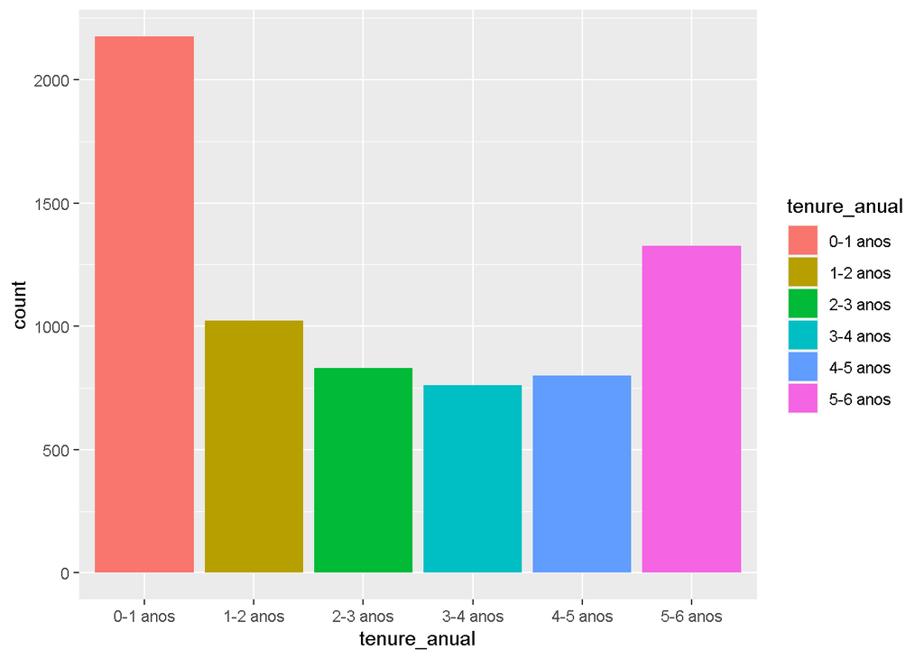

```r
ggplot(telco, aes(x=tenure_anual, fill = tenure_anual)) + geom_bar()
```

```r
summary(telco$TotalCharges)
```

```
##    Min. 1st Qu.  Median    Mean 3rd Qu.    Max.
##    18.8   388.6  1363.5  2213.8  3627.3  8672.5
```

```r
telco <- mutate(telco, total_charges_fct = TotalCharges)

telco$total_charges_fct[telco$TotalCharges >=0 & telco$TotalCharges <= 800] <- 'baixa'
telco$total_charges_fct[telco$TotalCharges > 800 & telco$TotalCharges <= 3000] <- 'media'
telco$total_charges_fct[telco$TotalCharges > 2500 & telco$TotalCharges <= 8672.5] <- 'alta'

telco$total_charges_fct <- as.factor(telco$total_charges_fct)
```

```r
table(telco$total_charges_fct)
```

```
##
##  alta baixa media
##  2386  2557  1978
```

### Plot da variável total_charges_fct

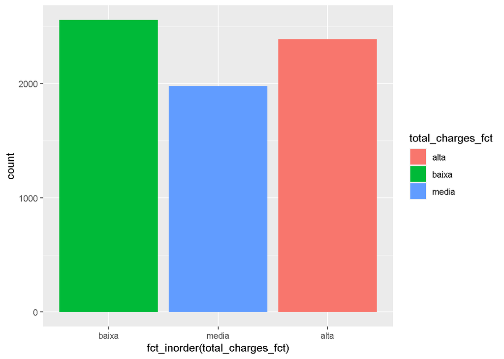

```r
ggplot(telco, aes(x=fct_inorder(total_charges_fct), fill = total_charges_fct)) + geom_bar()
```

### Transformando No internet service/phone service em “No”

Para as variáveis categóricas que possuem 3 categorias (“Yes”, “No” e “No internet service”), a categoria “No internet service” pode ser considerada como “No”.

```r
telco <- data.frame(lapply(telco, function(x) {
                  gsub("No internet service", "No", x)}))

telco <- data.frame(lapply(telco, function(x) {
                  gsub("No phone service", "No", x)}))
```

A função acima transformou toda as variáveis para “chr” novamente. Portanto, será feito a transformação para o tipo correto novamente.

```r
glimpse(telco)
```

```
## Rows: 6,921
## Columns: 23
## $ customerID        <chr> "7590-VHVEG", "5575-GNVDE", "3668-QPYBK", "7795-C...
## $ gender            <chr> "Female", "Male", "Male", "Male", "Female", "Fema...
## $ SeniorCitizen     <chr> "No", "No", "No", "No", "No", "No", "No", "No", "...
## $ Partner           <chr> "Yes", "No", "No", "No", "No", "No", "No", "No", ...
## $ Dependents        <chr> "No", "No", "No", "No", "No", "No", "Yes", "No", ...
## $ tenure            <chr> "1", "34", "2", "45", "2", "8", "22", "10", "28",...
## $ PhoneService      <chr> "No", "Yes", "Yes", "No", "Yes", "Yes", "Yes", "N...
## $ MultipleLines     <chr> "No", "No", "No", "No", "No", "Yes", "Yes", "No",...
## $ InternetService   <chr> "DSL", "DSL", "DSL", "DSL", "Fiber optic", "Fiber...
## $ OnlineSecurity    <chr> "No", "Yes", "Yes", "Yes", "No", "No", "No", "Yes...
## $ OnlineBackup      <chr> "Yes", "No", "Yes", "No", "No", "No", "Yes", "No"...
## $ DeviceProtection  <chr> "No", "Yes", "No", "Yes", "No", "Yes", "No", "No"...
## $ TechSupport       <chr> "No", "No", "No", "Yes", "No", "No", "No", "No", ...
## $ StreamingTV       <chr> "No", "No", "No", "No", "No", "Yes", "Yes", "No",...
## $ StreamingMovies   <chr> "No", "No", "No", "No", "No", "Yes", "No", "No", ...
## $ Contract          <chr> "Month-to-month", "One year", "Month-to-month", "...
## $ PaperlessBilling  <chr> "Yes", "No", "Yes", "No", "Yes", "Yes", "Yes", "N...
## $ PaymentMethod     <chr> "Electronic check", "Mailed check", "Mailed check...
## $ MonthlyCharges    <chr> "29.85", "56.95", "53.85", "42.3", "70.7", "99.65...
## $ TotalCharges      <chr> "29.85", "1889.5", "108.15", "1840.75", "151.65",...
## $ Churn             <chr> "No", "No", "Yes", "No", "Yes", "Yes", "No", "No"...
## $ tenure_anual      <chr> "0-1 anos", "2-3 anos", "0-1 anos", "3-4 anos", "...
## $ total_charges_fct <chr> "baixa", "media", "baixa", "media", "baixa", "med...
```

Transformando para “factor” as variaveis categoricas que estavam como “chr”

```r
cols <- c(2:5,7:18,21,22)
telco[,cols] <- lapply(telco[,cols], as.factor)
```

### Transformando para numérico as variáveis numéricas

```r
cols_num <- c(6,19,20)
telco[,cols_num] <- lapply(telco[,cols_num], as.numeric)
```

### Observando como ficou o dataset

```r
str(telco)
```

```
## 'data.frame':    6921 obs. of  23 variables:
##  $ customerID       : chr  "7590-VHVEG" "5575-GNVDE" "3668-QPYBK" "7795-CFOCW" ...
##  $ gender           : Factor w/ 2 levels "Female","Male": 1 2 2 2 1 1 2 1 1 2 ...
##  $ SeniorCitizen    : Factor w/ 2 levels "No","Yes": 1 1 1 1 1 1 1 1 1 1 ...
##  $ Partner          : Factor w/ 2 levels "No","Yes": 2 1 1 1 1 1 1 1 2 1 ...
##  $ Dependents       : Factor w/ 2 levels "No","Yes": 1 1 1 1 1 1 2 1 1 2 ...
##  $ tenure           : num  1 34 2 45 2 8 22 10 28 62 ...
##  $ PhoneService     : Factor w/ 2 levels "No","Yes": 1 2 2 1 2 2 2 1 2 2 ...
##  $ MultipleLines    : Factor w/ 2 levels "No","Yes": 1 1 1 1 1 2 2 1 2 1 ...
##  $ InternetService  : Factor w/ 3 levels "DSL","Fiber optic",..: 1 1 1 1 2 2 2 1 2 1 ...
##  $ OnlineSecurity   : Factor w/ 2 levels "No","Yes": 1 2 2 2 1 1 1 2 1 2 ...
##  $ OnlineBackup     : Factor w/ 2 levels "No","Yes": 2 1 2 1 1 1 2 1 1 2 ...
##  $ DeviceProtection : Factor w/ 2 levels "No","Yes": 1 2 1 2 1 2 1 1 2 1 ...
##  $ TechSupport      : Factor w/ 2 levels "No","Yes": 1 1 1 2 1 1 1 1 2 1 ...
##  $ StreamingTV      : Factor w/ 2 levels "No","Yes": 1 1 1 1 1 2 2 1 2 1 ...
##  $ StreamingMovies  : Factor w/ 2 levels "No","Yes": 1 1 1 1 1 2 1 1 2 1 ...
##  $ Contract         : Factor w/ 3 levels "Month-to-month",..: 1 2 1 2 1 1 1 1 1 2 ...
##  $ PaperlessBilling : Factor w/ 2 levels "No","Yes": 2 1 2 1 2 2 2 1 2 1 ...
##  $ PaymentMethod    : Factor w/ 4 levels "Bank transfer (automatic)",..: 3 4 4 1 3 3 2 4 3 1 ...
##  $ MonthlyCharges   : num  29.9 57 53.9 42.3 70.7 ...
##  $ TotalCharges     : num  29.9 1889.5 108.2 1840.8 151.7 ...
##  $ Churn            : Factor w/ 2 levels "No","Yes": 1 1 2 1 2 2 1 1 2 1 ...
##  $ tenure_anual     : Factor w/ 6 levels "0-1 anos","1-2 anos",..: 1 3 1 4 1 1 2 1 3 6 ...
##  $ total_charges_fct: chr  "baixa" "media" "baixa" "media" ...
```

### Criando variáveis Dummy

A seguir serão criadas variáveis dummy a partir das variáveis categóricas

```r
glimpse(telco)
```

```
## Rows: 6,921
## Columns: 23
## $ customerID        <chr> "7590-VHVEG", "5575-GNVDE", "3668-QPYBK", "7795-C...
## $ gender            <fct> Female, Male, Male, Male, Female, Female, Male, F...
## $ SeniorCitizen     <fct> No, No, No, No, No, No, No, No, No, No, No, No, N...
## $ Partner           <fct> Yes, No, No, No, No, No, No, No, Yes, No, Yes, No...
## $ Dependents        <fct> No, No, No, No, No, No, Yes, No, No, Yes, Yes, No...
## $ tenure            <dbl> 1, 34, 2, 45, 2, 8, 22, 10, 28, 62, 13, 16, 58, 4...
## $ PhoneService      <fct> No, Yes, Yes, No, Yes, Yes, Yes, No, Yes, Yes, Ye...
## $ MultipleLines     <fct> No, No, No, No, No, Yes, Yes, No, Yes, No, No, No...
## $ InternetService   <fct> DSL, DSL, DSL, DSL, Fiber optic, Fiber optic, Fib...
## $ OnlineSecurity    <fct> No, Yes, Yes, Yes, No, No, No, Yes, No, Yes, Yes,...
## $ OnlineBackup      <fct> Yes, No, Yes, No, No, No, Yes, No, No, Yes, No, N...
## $ DeviceProtection  <fct> No, Yes, No, Yes, No, Yes, No, No, Yes, No, No, N...
## $ TechSupport       <fct> No, No, No, Yes, No, No, No, No, Yes, No, No, No,...
## $ StreamingTV       <fct> No, No, No, No, No, Yes, Yes, No, Yes, No, No, No...
## $ StreamingMovies   <fct> No, No, No, No, No, Yes, No, No, Yes, No, No, No,...
## $ Contract          <fct> Month-to-month, One year, Month-to-month, One yea...
## $ PaperlessBilling  <fct> Yes, No, Yes, No, Yes, Yes, Yes, No, Yes, No, Yes...
## $ PaymentMethod     <fct> Electronic check, Mailed check, Mailed check, Ban...
## $ MonthlyCharges    <dbl> 29.85, 56.95, 53.85, 42.30, 70.70, 99.65, 89.10, ...
## $ TotalCharges      <dbl> 29.85, 1889.50, 108.15, 1840.75, 151.65, 820.50, ...
## $ Churn             <fct> No, No, Yes, No, Yes, Yes, No, No, Yes, No, No, N...
## $ tenure_anual      <fct> 0-1 anos, 2-3 anos, 0-1 anos, 3-4 anos, 0-1 anos,...
## $ total_charges_fct <chr> "baixa", "media", "baixa", "media", "baixa", "med...
```

O argumento fullRank foi adicionado para evitar duplicação de informação nas variáveis (por exemplo, em vez de uma coluna com observações “No” e outra coluna para “Yes”, será uma coluna representando com 0 (“No”) e 1 (“Yes”))

```r
telco_categ <- telco[,-c(1,6,19,20,21)]
dmy <- dummyVars(" ~ .", data = telco_categ, fullRank = T)
data_onehot <- data.frame(predict(dmy, newdata = telco_categ))
```

```r
glimpse(data_onehot)
```

```
## Rows: 6,921
## Columns: 27
## $ gender.Male                           <dbl> 0, 1, 1, 1, 0, 0, 1, 0, 0, 1,...
## $ SeniorCitizen.Yes                     <dbl> 0, 0, 0, 0, 0, 0, 0, 0, 0, 0,...
## $ Partner.Yes                           <dbl> 1, 0, 0, 0, 0, 0, 0, 0, 1, 0,...
## $ Dependents.Yes                        <dbl> 0, 0, 0, 0, 0, 0, 1, 0, 0, 1,...
## $ PhoneService.Yes                      <dbl> 0, 1, 1, 0, 1, 1, 1, 0, 1, 1,...
## $ MultipleLines.Yes                     <dbl> 0, 0, 0, 0, 0, 1, 1, 0, 1, 0,...
## $ InternetService.Fiber.optic           <dbl> 0, 0, 0, 0, 1, 1, 1, 0, 1, 0,...
## $ InternetService.No                    <dbl> 0, 0, 0, 0, 0, 0, 0, 0, 0, 0,...
## $ OnlineSecurity.Yes                    <dbl> 0, 1, 1, 1, 0, 0, 0, 1, 0, 1,...
## $ OnlineBackup.Yes                      <dbl> 1, 0, 1, 0, 0, 0, 1, 0, 0, 1,...
## $ DeviceProtection.Yes                  <dbl> 0, 1, 0, 1, 0, 1, 0, 0, 1, 0,...
## $ TechSupport.Yes                       <dbl> 0, 0, 0, 1, 0, 0, 0, 0, 1, 0,...
## $ StreamingTV.Yes                       <dbl> 0, 0, 0, 0, 0, 1, 1, 0, 1, 0,...
## $ StreamingMovies.Yes                   <dbl> 0, 0, 0, 0, 0, 1, 0, 0, 1, 0,...
## $ Contract.One.year                     <dbl> 0, 1, 0, 1, 0, 0, 0, 0, 0, 1,...
## $ Contract.Two.year                     <dbl> 0, 0, 0, 0, 0, 0, 0, 0, 0, 0,...
## $ PaperlessBilling.Yes                  <dbl> 1, 0, 1, 0, 1, 1, 1, 0, 1, 0,...
## $ PaymentMethod.Credit.card..automatic. <dbl> 0, 0, 0, 0, 0, 0, 1, 0, 0, 0,...
## $ PaymentMethod.Electronic.check        <dbl> 1, 0, 0, 0, 1, 1, 0, 0, 1, 0,...
## $ PaymentMethod.Mailed.check            <dbl> 0, 1, 1, 0, 0, 0, 0, 1, 0, 0,...
## $ tenure_anual.1.2.anos                 <dbl> 0, 0, 0, 0, 0, 0, 1, 0, 0, 0,...
## $ tenure_anual.2.3.anos                 <dbl> 0, 1, 0, 0, 0, 0, 0, 0, 1, 0,...
## $ tenure_anual.3.4.anos                 <dbl> 0, 0, 0, 1, 0, 0, 0, 0, 0, 0,...
## $ tenure_anual.4.5.anos                 <dbl> 0, 0, 0, 0, 0, 0, 0, 0, 0, 0,...
## $ tenure_anual.5.6.anos                 <dbl> 0, 0, 0, 0, 0, 0, 0, 0, 0, 1,...
## $ total_charges_fctbaixa                <dbl> 1, 0, 1, 0, 1, 0, 0, 1, 0, 0,...
## $ total_charges_fctmedia                <dbl> 0, 1, 0, 1, 0, 1, 1, 0, 0, 0,...
```

```r
telco_num <- telco[,c(6,19,20,21)]
telco_bind <- cbind(data_onehot, telco_num)
```

```r
glimpse(telco_bind)
```

```
## Rows: 6,921
## Columns: 31
## $ gender.Male                           <dbl> 0, 1, 1, 1, 0, 0, 1, 0, 0, 1,...
## $ SeniorCitizen.Yes                     <dbl> 0, 0, 0, 0, 0, 0, 0, 0, 0, 0,...
## $ Partner.Yes                           <dbl> 1, 0, 0, 0, 0, 0, 0, 0, 1, 0,...
## $ Dependents.Yes                        <dbl> 0, 0, 0, 0, 0, 0, 1, 0, 0, 1,...
## $ PhoneService.Yes                      <dbl> 0, 1, 1, 0, 1, 1, 1, 0, 1, 1,...
## $ MultipleLines.Yes                     <dbl> 0, 0, 0, 0, 0, 1, 1, 0, 1, 0,...
## $ InternetService.Fiber.optic           <dbl> 0, 0, 0, 0, 1, 1, 1, 0, 1, 0,...
## $ InternetService.No                    <dbl> 0, 0, 0, 0, 0, 0, 0, 0, 0, 0,...
## $ OnlineSecurity.Yes                    <dbl> 0, 1, 1, 1, 0, 0, 0, 1, 0, 1,...
## $ OnlineBackup.Yes                      <dbl> 1, 0, 1, 0, 0, 0, 1, 0, 0, 1,...
## $ DeviceProtection.Yes                  <dbl> 0, 1, 0, 1, 0, 1, 0, 0, 1, 0,...
## $ TechSupport.Yes                       <dbl> 0, 0, 0, 1, 0, 0, 0, 0, 1, 0,...
## $ StreamingTV.Yes                       <dbl> 0, 0, 0, 0, 0, 1, 1, 0, 1, 0,...
```

[output cut: 18 more lines]

## Análise de Correlação para as variáveis numéricas

A variável tenure está altamente correlacionada com TotalCharges (0.821), o que indica que uma delas deve ser retirada para evitar que o modelo apresente autocorrelação. A variável MonthlyCharges e TotalCharges possuem correlação moderada (0.639)

```r
telco_correlacao <- cor(telco_bind[,c(28,29,30)])
telco_correlacao
```

```
##                   tenure MonthlyCharges TotalCharges
## tenure         1.0000000      0.2269803    0.8219675
## MonthlyCharges 0.2269803      1.0000000    0.6390145
## TotalCharges   0.8219675      0.6390145    1.0000000
```

### Gráfico das correlações

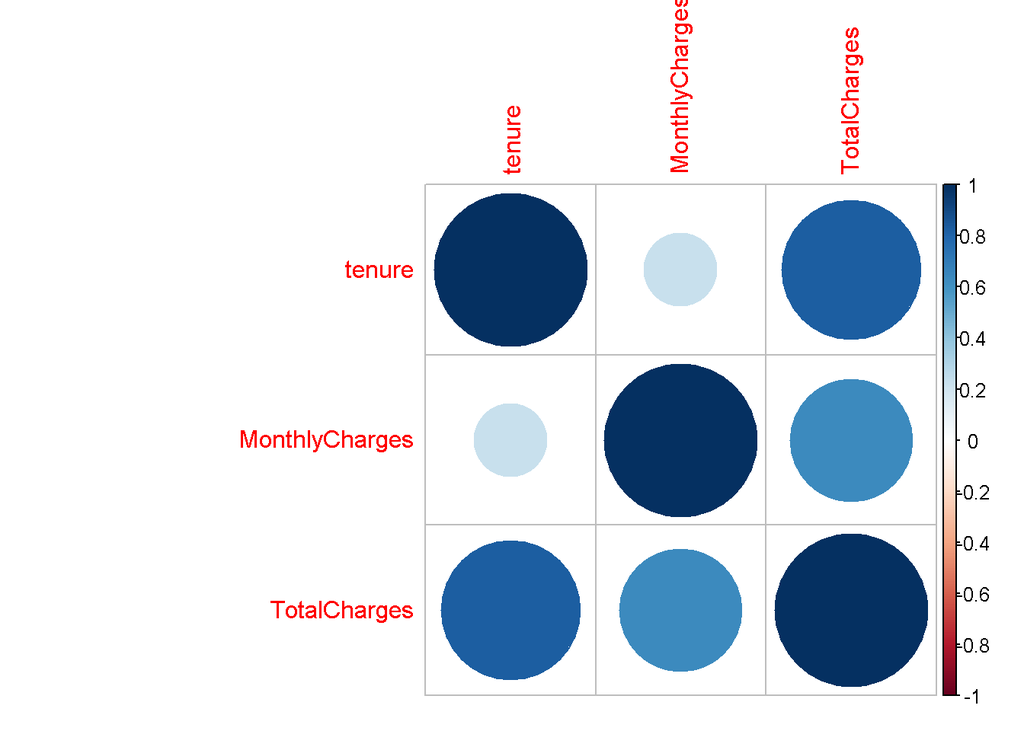

```r
corrplot(telco_correlacao)
```

## Modelagem

### Modelos GLM

```r
telco_num_scale <- scale(telco_bind[,c(28,29,30)], center=T, scale=T)
telco_bind_scale <- cbind(telco_bind[,-c(28,29,30)],telco_num_scale)
```

```r
set.seed(314)
options(warn=-1)
trainIndex <- createDataPartition(telco_bind_scale$Churn,p=.7,list=FALSE)
treino <- telco_bind_scale[trainIndex,]
teste <- telco_bind_scale[-trainIndex,]

set.seed(314)
options(warn=-1)
trainIndex <- createDataPartition(telco$Churn,p=.7,list=FALSE)
treino2 <- telco[trainIndex,]
teste2 <- telco[-trainIndex,]

model <- glm(Churn~.,data=treino, family="binomial")
summary(model)
```

```
##
## Call:
## glm(formula = Churn ~ ., family = "binomial", data = treino)
##
## Deviance Residuals:
##     Min       1Q   Median       3Q      Max
## -2.0853  -0.6254  -0.2014   0.5250   3.6264
##
## Coefficients:
##                                        Estimate Std. Error z value Pr(>|z|)
## (Intercept)                           -4.550059   1.719155  -2.647 0.008129 **
## gender.Male                           -0.019734   0.082737  -0.239 0.811485
## SeniorCitizen.Yes                      0.295190   0.110617   2.669 0.007617 **
## Partner.Yes                            0.046925   0.098721   0.475 0.634551
## Dependents.Yes                         0.005188   0.114156   0.045 0.963750
## PhoneService.Yes                       0.880289   0.859800   1.024 0.305916
## MultipleLines.Yes                      0.622530   0.234421   2.656 0.007916 **
## InternetService.Fiber.optic            2.461131   1.063123   2.315 0.020613 *
## InternetService.No                    -2.373213   1.073247  -2.211 0.027019 *
## OnlineSecurity.Yes                    -0.015852   0.235036  -0.067 0.946226
## OnlineBackup.Yes                       0.205107   0.231184   0.887 0.374971
## DeviceProtection.Yes                   0.408201   0.233296   1.750 0.080168 .
## TechSupport.Yes                        0.017880   0.238695   0.075 0.940289
## StreamingTV.Yes                        0.778958   0.432230   1.802 0.071516 .
## StreamingMovies.Yes                    1.013757   0.435595   2.327 0.019950 *
## Contract.One.year                     -0.884994   0.144859  -6.109 1.00e-09 ***
## Contract.Two.year                     -1.888740   0.309155  -6.109 1.00e-09 ***
## PaperlessBilling.Yes                   0.386510   0.094099   4.107 4.00e-05 ***
## PaymentMethod.Credit.card..automatic. -0.083003   0.149236  -0.556 0.578085
## PaymentMethod.Electronic.check         0.177802   0.122770   1.448 0.147547
## PaymentMethod.Mailed.check            -0.129874   0.144975  -0.896 0.370339
## tenure_anual.1.2.anos                  0.156733   0.213888   0.733 0.463691
## tenure_anual.2.3.anos                  0.628874   0.340161   1.849 0.064493 .
## tenure_anual.3.4.anos                  1.949163   0.476206   4.093 4.26e-05 ***
## tenure_anual.4.5.anos                  2.594010   0.611454   4.242 2.21e-05 ***
## tenure_anual.5.6.anos                  2.197232   0.818603   2.684 0.007272 **
## total_charges_fctbaixa                -1.276252   0.324052  -3.938 8.20e-05 ***
## total_charges_fctmedia                -0.744905   0.230738  -3.228 0.001245 **
## tenure                                -1.957958   0.348299  -5.621 1.89e-08 ***
## MonthlyCharges                        -1.838467   1.264392  -1.454 0.145937
## TotalCharges                          -0.943366   0.258617  -3.648 0.000265 ***
## ---
## Signif. codes:  0 '***' 0.001 '**' 0.01 '*' 0.05 '.' 0.1 ' ' 1
##
## (Dispersion parameter for binomial family taken to be 1)
##
##     Null deviance: 5492.6  on 4845  degrees of freedom
## Residual deviance: 3612.2  on 4815  degrees of freedom
## AIC: 3674.2
##
## Number of Fisher Scoring iterations: 7
```

Algumas variaveis apresentaram um Variance inflation factor muito elevado. Por isso irei aplicar um modelo stepAIC, para considerar as melhores variaveis com base no AIC.

```r
vif(model)
```

```
##                           gender.Male                     SeniorCitizen.Yes
##                              1.007427                              1.156219
##                           Partner.Yes                        Dependents.Yes
##                              1.345029                              1.297453
##                      PhoneService.Yes                     MultipleLines.Yes
##                             41.733322                              7.663543
##           InternetService.Fiber.optic                    InternetService.No
##                            163.732244                             67.032311
##                    OnlineSecurity.Yes                      OnlineBackup.Yes
##                              5.040973                              6.406762
##                  DeviceProtection.Yes                       TechSupport.Yes
##                              6.430086                              5.181585
##                       StreamingTV.Yes                   StreamingMovies.Yes
##                             25.510555                             26.398429
##                     Contract.One.year                     Contract.Two.year
##                              1.275254                              1.173730
##                  PaperlessBilling.Yes PaymentMethod.Credit.card..automatic.
##                              1.129528                              1.647849
##        PaymentMethod.Electronic.check            PaymentMethod.Mailed.check
##                              2.212518                              2.121346
##                 tenure_anual.1.2.anos                 tenure_anual.2.3.anos
##                              3.966387                              7.239956
##                 tenure_anual.3.4.anos                 tenure_anual.4.5.anos
##                             13.227220                             16.222555
##                 tenure_anual.5.6.anos                total_charges_fctbaixa
##                              5.717210                             15.456166
##                total_charges_fctmedia                                tenure
##                              6.182767                             37.908631
##                        MonthlyCharges                          TotalCharges
##                            732.817545                             20.768138
```

```r
model_stepAic <- stepAIC(model,direction ="both",trace=F)
summary(model_stepAic)
```

```
##
## Call:
## glm(formula = Churn ~ SeniorCitizen.Yes + PhoneService.Yes +
##     MultipleLines.Yes + InternetService.Fiber.optic + InternetService.No +
##     OnlineBackup.Yes + DeviceProtection.Yes + StreamingTV.Yes +
##     StreamingMovies.Yes + Contract.One.year + Contract.Two.year +
##     PaperlessBilling.Yes + PaymentMethod.Electronic.check + tenure_anual.2.3.anos +
##     tenure_anual.3.4.anos + tenure_anual.4.5.anos + tenure_anual.5.6.anos +
##     total_charges_fctbaixa + total_charges_fctmedia + tenure +
##     MonthlyCharges + TotalCharges, family = "binomial", data = treino)
##
## Deviance Residuals:
##     Min       1Q   Median       3Q      Max
## -2.0818  -0.6275  -0.2009   0.5180   3.6201
##
## Coefficients:
##                                Estimate Std. Error z value Pr(>|z|)
## (Intercept)                    -4.40534    0.61606  -7.151 8.62e-13 ***
## SeniorCitizen.Yes               0.30050    0.10813   2.779 0.005454 **
## PhoneService.Yes                0.87810    0.33648   2.610 0.009064 **
## MultipleLines.Yes               0.62348    0.12247   5.091 3.56e-07 ***
## InternetService.Fiber.optic     2.46515    0.36458   6.762 1.36e-11 ***
## InternetService.No             -2.37647    0.43974  -5.404 6.51e-08 ***
## OnlineBackup.Yes                0.20454    0.12273   1.667 0.095608 .
## DeviceProtection.Yes            0.40950    0.12772   3.206 0.001345 **
## StreamingTV.Yes                 0.78160    0.17827   4.384 1.16e-05 ***
## StreamingMovies.Yes             1.01482    0.17838   5.689 1.28e-08 ***
## Contract.One.year              -0.87986    0.14445  -6.091 1.12e-09 ***
## Contract.Two.year              -1.88777    0.30827  -6.124 9.13e-10 ***
## PaperlessBilling.Yes            0.38696    0.09382   4.124 3.72e-05 ***
## PaymentMethod.Electronic.check  0.25104    0.08893   2.823 0.004757 **
## tenure_anual.2.3.anos           0.43481    0.22024   1.974 0.048353 *
## tenure_anual.3.4.anos           1.68081    0.32273   5.208 1.91e-07 ***
## tenure_anual.4.5.anos           2.25623    0.42844   5.266 1.39e-07 ***
## tenure_anual.5.6.anos           1.78581    0.62362   2.864 0.004188 **
## total_charges_fctbaixa         -1.31382    0.32009  -4.105 4.05e-05 ***
## total_charges_fctmedia         -0.73108    0.22970  -3.183 0.001458 **
## tenure                         -1.79173    0.29567  -6.060 1.36e-09 ***
## MonthlyCharges                 -1.83642    0.44295  -4.146 3.39e-05 ***
## TotalCharges                   -0.94778    0.25706  -3.687 0.000227 ***
## ---
## Signif. codes:  0 '***' 0.001 '**' 0.01 '*' 0.05 '.' 0.1 ' ' 1
##
## (Dispersion parameter for binomial family taken to be 1)
##
##     Null deviance: 5492.6  on 4845  degrees of freedom
## Residual deviance: 3614.0  on 4823  degrees of freedom
## AIC: 3660
##
## Number of Fisher Scoring iterations: 7
```

```r
vif(model_stepAic)
```

```
##              SeniorCitizen.Yes               PhoneService.Yes
##                       1.105865                       6.410125
##              MultipleLines.Yes    InternetService.Fiber.optic
##                       2.092213                      19.268930
##             InternetService.No               OnlineBackup.Yes
##                      11.247094                       1.806037
##           DeviceProtection.Yes                StreamingTV.Yes
##                       1.928569                       4.340490
##            StreamingMovies.Yes              Contract.One.year
##                       4.428248                       1.268655
##              Contract.Two.year           PaperlessBilling.Yes
##                       1.167329                       1.123762
## PaymentMethod.Electronic.check          tenure_anual.2.3.anos
##                       1.161577                       3.037407
##          tenure_anual.3.4.anos          tenure_anual.4.5.anos
##                       6.093914                       7.974524
##          tenure_anual.5.6.anos         total_charges_fctbaixa
##                       3.319486                      15.090159
##         total_charges_fctmedia                         tenure
##                       6.122031                      27.425558
##                 MonthlyCharges                   TotalCharges
##                      89.944402                      20.574675
```

Devido ao elevado VIF retirei MonthlyCharges, TotalCharges, total_charges_fctbaixa, tenure, StreamingTV.Yes, OnlineBackup.Yes, DeviceProtection.Yes

```r
model1 <- glm(formula = Churn ~ SeniorCitizen.Yes + PhoneService.Yes +
    InternetService.Fiber.optic + InternetService.No + MultipleLines.Yes +
    StreamingMovies.Yes + Contract.One.year + Contract.Two.year +
    PaperlessBilling.Yes + PaymentMethod.Electronic.check + tenure_anual.2.3.anos +
    tenure_anual.3.4.anos + tenure_anual.4.5.anos + tenure_anual.5.6.anos +
    total_charges_fctmedia, family = "binomial", data = treino)
summary(model1)
```

```
##
## Call:
## glm(formula = Churn ~ SeniorCitizen.Yes + PhoneService.Yes +
##     InternetService.Fiber.optic + InternetService.No + MultipleLines.Yes +
##     StreamingMovies.Yes + Contract.One.year + Contract.Two.year +
##     PaperlessBilling.Yes + PaymentMethod.Electronic.check + tenure_anual.2.3.anos +
##     tenure_anual.3.4.anos + tenure_anual.4.5.anos + tenure_anual.5.6.anos +
##     total_charges_fctmedia, family = "binomial", data = treino)
##
## Deviance Residuals:
##     Min       1Q   Median       3Q      Max
## -1.8344  -0.6488  -0.2047   0.6905   3.6339
##
## Coefficients:
##                                Estimate Std. Error z value Pr(>|z|)
## (Intercept)                    -0.54886    0.14904  -3.683 0.000231 ***
## SeniorCitizen.Yes               0.32353    0.10436   3.100 0.001935 **
## PhoneService.Yes               -0.40291    0.15652  -2.574 0.010047 *
## InternetService.Fiber.optic     0.92436    0.11109   8.321  < 2e-16 ***
## InternetService.No             -0.70718    0.15596  -4.534 5.78e-06 ***
## MultipleLines.Yes               0.16445    0.09562   1.720 0.085485 .
## StreamingMovies.Yes             0.30535    0.09215   3.314 0.000920 ***
## Contract.One.year              -1.10968    0.13856  -8.009 1.16e-15 ***
## Contract.Two.year              -2.19624    0.29986  -7.324 2.40e-13 ***
## PaperlessBilling.Yes            0.38111    0.09110   4.183 2.87e-05 ***
## PaymentMethod.Electronic.check  0.32984    0.08563   3.852 0.000117 ***
## tenure_anual.2.3.anos          -1.03010    0.13326  -7.730 1.08e-14 ***
## tenure_anual.3.4.anos          -0.97626    0.14517  -6.725 1.76e-11 ***
## tenure_anual.4.5.anos          -1.64079    0.17076  -9.609  < 2e-16 ***
## tenure_anual.5.6.anos          -3.61785    0.36393  -9.941  < 2e-16 ***
## total_charges_fctmedia         -0.49958    0.09690  -5.156 2.53e-07 ***
## ---
## Signif. codes:  0 '***' 0.001 '**' 0.01 '*' 0.05 '.' 0.1 ' ' 1
##
## (Dispersion parameter for binomial family taken to be 1)
##
##     Null deviance: 5492.6  on 4845  degrees of freedom
## Residual deviance: 3762.0  on 4830  degrees of freedom
## AIC: 3794
##
## Number of Fisher Scoring iterations: 7
```

```r
vif(model1)
```

```
##              SeniorCitizen.Yes               PhoneService.Yes
##                       1.090662                       1.386853
##    InternetService.Fiber.optic             InternetService.No
##                       1.871459                       1.445119
##              MultipleLines.Yes            StreamingMovies.Yes
##                       1.354159                       1.248885
##              Contract.One.year              Contract.Two.year
##                       1.186696                       1.101473
##           PaperlessBilling.Yes PaymentMethod.Electronic.check
##                       1.111372                       1.138803
##          tenure_anual.2.3.anos          tenure_anual.3.4.anos
##                       1.129542                       1.230899
##          tenure_anual.4.5.anos          tenure_anual.5.6.anos
##                       1.264843                       1.130482
##         total_charges_fctmedia
##                       1.117432
```

Removi a variável total_charges_fctmedia

```r
model2 <- glm(formula = Churn ~ SeniorCitizen.Yes + PhoneService.Yes +
    MultipleLines.Yes + InternetService.Fiber.optic + InternetService.No
     + DeviceProtection.Yes + StreamingTV.Yes +
    StreamingMovies.Yes + Contract.One.year + Contract.Two.year +
    PaperlessBilling.Yes + PaymentMethod.Electronic.check +
    tenure_anual.1.2.anos + tenure_anual.2.3.anos + tenure_anual.3.4.anos + tenure_anual.4.5.anos + tenure_anual.5.6.anos, family = "binomial",
    data = treino)
summary(model2)
```

```
##
## Call:
## glm(formula = Churn ~ SeniorCitizen.Yes + PhoneService.Yes +
##     MultipleLines.Yes + InternetService.Fiber.optic + InternetService.No +
##     DeviceProtection.Yes + StreamingTV.Yes + StreamingMovies.Yes +
##     Contract.One.year + Contract.Two.year + PaperlessBilling.Yes +
##     PaymentMethod.Electronic.check + tenure_anual.1.2.anos +
##     tenure_anual.2.3.anos + tenure_anual.3.4.anos + tenure_anual.4.5.anos +
##     tenure_anual.5.6.anos, family = "binomial", data = treino)
##
## Deviance Residuals:
##     Min       1Q   Median       3Q      Max
## -1.9334  -0.6344  -0.2034   0.5979   3.6518
##
## Coefficients:
##                                Estimate Std. Error z value Pr(>|z|)
## (Intercept)                    -0.48211    0.15001  -3.214 0.001310 **
## SeniorCitizen.Yes               0.35327    0.10527   3.356 0.000791 ***
## PhoneService.Yes               -0.40704    0.15618  -2.606 0.009155 **
## MultipleLines.Yes               0.21945    0.09731   2.255 0.024119 *
## InternetService.Fiber.optic     0.93294    0.11241   8.300  < 2e-16 ***
## InternetService.No             -0.61168    0.15701  -3.896 9.79e-05 ***
## DeviceProtection.Yes           -0.01844    0.09865  -0.187 0.851754
## StreamingTV.Yes                 0.07045    0.09892   0.712 0.476354
## StreamingMovies.Yes             0.32702    0.09912   3.299 0.000970 ***
## Contract.One.year              -1.03907    0.14058  -7.391 1.45e-13 ***
## Contract.Two.year              -2.13498    0.30177  -7.075 1.50e-12 ***
## PaperlessBilling.Yes            0.38447    0.09211   4.174 2.99e-05 ***
## PaymentMethod.Electronic.check  0.30307    0.08663   3.498 0.000468 ***
## tenure_anual.1.2.anos          -0.91927    0.11509  -7.987 1.38e-15 ***
## tenure_anual.2.3.anos          -1.39490    0.13877 -10.052  < 2e-16 ***
## tenure_anual.3.4.anos          -1.23270    0.15144  -8.140 3.96e-16 ***
## tenure_anual.4.5.anos          -1.84946    0.17509 -10.563  < 2e-16 ***
## tenure_anual.5.6.anos          -3.84327    0.36787 -10.447  < 2e-16 ***
## ---
## Signif. codes:  0 '***' 0.001 '**' 0.01 '*' 0.05 '.' 0.1 ' ' 1
##
## (Dispersion parameter for binomial family taken to be 1)
##
##     Null deviance: 5492.6  on 4845  degrees of freedom
## Residual deviance: 3722.2  on 4828  degrees of freedom
## AIC: 3758.2
##
## Number of Fisher Scoring iterations: 7
```

Agora as variaveis não apresentaram um VIF elevado.

```r
vif(model2)
```

```
##              SeniorCitizen.Yes               PhoneService.Yes
##                       1.096258                       1.398378
##              MultipleLines.Yes    InternetService.Fiber.optic
##                       1.378282                       1.893085
##             InternetService.No           DeviceProtection.Yes
##                       1.444840                       1.198055
##                StreamingTV.Yes            StreamingMovies.Yes
##                       1.394499                       1.423256
##              Contract.One.year              Contract.Two.year
##                       1.216050                       1.117957
##           PaperlessBilling.Yes PaymentMethod.Electronic.check
##                       1.120678                       1.147378
##          tenure_anual.1.2.anos          tenure_anual.2.3.anos
##                       1.202866                       1.255549
##          tenure_anual.3.4.anos          tenure_anual.4.5.anos
##                       1.370827                       1.340176
##          tenure_anual.5.6.anos
##                       1.157027
```

```r
predictions1 <- predict(model, teste, type = "response")
predictions2 <- predict(model_stepAic, teste, type = "response")
predictions3 <- predict(model1, teste, type = "response")
predictions4 <- predict(model2, teste, type = "response")
```

Testei com os 4 modelos criados acima

```r
dfPref <- ifelse(predictions1 > 0.5, "Yes", "No")
dfPref <- as.factor(dfPref)
caret::confusionMatrix(dfPref, as.factor(teste$Churn), positive = "Yes")
```

```
## Confusion Matrix and Statistics
##
##           Reference
## Prediction   No  Yes
##        No  1394  228
##        Yes  154  299
##
##                Accuracy : 0.8159
##                  95% CI : (0.7985, 0.8324)
##     No Information Rate : 0.746
##     P-Value [Acc > NIR] : 2.343e-14
##
##                   Kappa : 0.4906
##
##  Mcnemar's Test P-Value : 0.0001877
##
##             Sensitivity : 0.5674
##             Specificity : 0.9005
##          Pos Pred Value : 0.6600
##          Neg Pred Value : 0.8594
##              Prevalence : 0.2540
##          Detection Rate : 0.1441
##    Detection Prevalence : 0.2183
##       Balanced Accuracy : 0.7339
##
##        'Positive' Class : Yes
##
```